# Loan Data Exploration

by Cyril Odoi

### Preliminary Wrangling

This document explores a dataset containing key requirements for credit application for approximately 114,000 loan applications.

## 1.Gathering data

```python
# import all packages and set plots to be embedded inline
import numpy as np
import pandas as pd
import matplotlib.pyplot as plt
import seaborn as sb
import os
%matplotlib inline
```

```python
#load dataset into pandas df, print stats
cwd = os.getcwd()
pd.options.display.max_columns = 999
pd.options.display.max_rows = 999
loan = pd.read_csv('LoanData.csv')
```

```python
print(loan.shape)
print(loan.dtypes)
loan.head()
```

```
(113937, 81)
ListingKey                              object
ListingNumber                            int64
ListingCreationDate                     object
CreditGrade                             object
Term                                     int64
LoanStatus                              object
ClosedDate                              object
BorrowerAPR                            float64
BorrowerRate                           float64
LenderYield                            float64
EstimatedEffectiveYield                float64
EstimatedLoss                          float64
EstimatedReturn                        float64
ProsperRating (numeric)                float64
ProsperRating (Alpha)                   object
ProsperScore                           float64
ListingCategory (numeric)                int64
BorrowerState                           object
Occupation                              object
EmploymentStatus                        object
EmploymentStatusDuration               float64
IsBorrowerHomeowner                       bool
CurrentlyInGroup                          bool
GroupKey                                object
DateCreditPulled                        object
CreditScoreRangeLower                  float64
CreditScoreRangeUpper                  float64
FirstRecordedCreditLine                 object
CurrentCreditLines                     float64
OpenCreditLines                        float64
TotalCreditLinespast7years             float64
OpenRevolvingAccounts                    int64
OpenRevolvingMonthlyPayment            float64
InquiriesLast6Months                   float64
TotalInquiries                         float64
CurrentDelinquencies                   float64
AmountDelinquent                       float64
DelinquenciesLast7Years                float64
PublicRecordsLast10Years               float64
```

[output cut: 28 more lines]

```
MonthlyLoanPayment                     float64
LP_CustomerPayments                    float64
LP_CustomerPrincipalPayments           float64
LP_InterestandFees                     float64
LP_ServiceFees                         float64
LP_CollectionFees                      float64
LP_GrossPrincipalLoss                  float64
LP_NetPrincipalLoss                    float64
LP_NonPrincipalRecoverypayments        float64
PercentFunded                          float64
Recommendations                          int64
InvestmentFromFriendsCount               int64
InvestmentFromFriendsAmount            float64
Investors                                int64
dtype: object
```

|  | ListingKey | ListingNumber | ListingCreationDate | CreditGrade | Term | LoanStatus | ClosedDate | BorrowerAPR | BorrowerRate | LenderYield | EstimatedEffectiveYield | EstimatedLoss | EstimatedReturn | ProsperRating (numeric) | ProsperRating (Alpha) | ProsperScore | ListingCategory (numeric) | BorrowerState | Occupation | EmploymentStatus | EmploymentStatusDuration | IsBorrowerHomeowner | CurrentlyInGroup | GroupKey | DateCreditPulled | CreditScoreRangeLower | CreditScoreRangeUpper | FirstRecordedCreditLine | CurrentCreditLines | … |
| --- | --- | --- | --- | --- | --- | --- | --- | --- | --- | --- | --- | --- | --- | --- | --- | --- | --- | --- | --- | --- | --- | --- | --- | --- | --- | --- | --- | --- | --- | --- |
| 0 | 1021339766868145413AB3B | 193129 | 2007-08-26 19:09:29.263000000 | C | 36 | Completed | 2009-08-14 00:00:00 | 0.16516 | 0.1580 | 0.1380 | NaN | NaN | NaN | NaN | NaN | NaN | 0 | CO | Other | Self-employed | 2.0 | True | True | NaN | 2007-08-26 18:41:46.780000000 | 640.0 | 659.0 | 2001-10-11 00:00:00 | 5.0 | … |
| 1 | 10273602499503308B223C1 | 1209647 | 2014-02-27 08:28:07.900000000 | NaN | 36 | Current | NaN | 0.12016 | 0.0920 | 0.0820 | 0.07960 | 0.0249 | 0.05470 | 6.0 | A | 7.0 | 2 | CO | Professional | Employed | 44.0 | False | False | NaN | 2014-02-27 08:28:14 | 680.0 | 699.0 | 1996-03-18 00:00:00 | 14.0 | … |
| 2 | 0EE9337825851032864889A | 81716 | 2007-01-05 15:00:47.090000000 | HR | 36 | Completed | 2009-12-17 00:00:00 | 0.28269 | 0.2750 | 0.2400 | NaN | NaN | NaN | NaN | NaN | NaN | 0 | GA | Other | Not available | NaN | False | True | 783C3371218786870A73D20 | 2007-01-02 14:09:10.060000000 | 480.0 | 499.0 | 2002-07-27 00:00:00 | NaN | … |
| 3 | 0EF5356002482715299901A | 658116 | 2012-10-22 11:02:35.010000000 | NaN | 36 | Current | NaN | 0.12528 | 0.0974 | 0.0874 | 0.08490 | 0.0249 | 0.06000 | 6.0 | A | 9.0 | 16 | GA | Skilled Labor | Employed | 113.0 | True | False | NaN | 2012-10-22 11:02:32 | 800.0 | 819.0 | 1983-02-28 00:00:00 | 5.0 | … |
| 4 | 0F023589499656230C5E3E2 | 909464 | 2013-09-14 18:38:39.097000000 | NaN | 36 | Current | NaN | 0.24614 | 0.2085 | 0.1985 | 0.18316 | 0.0925 | 0.09066 | 3.0 | D | 4.0 | 2 | MN | Executive | Employed | 44.0 | True | False | NaN | 2013-09-14 18:38:44 | 680.0 | 699.0 | 2004-02-20 00:00:00 | 19.0 | … |

```python
#Which period had the most loan originations?
loan.LoanOriginationQuarter.value_counts()
```

```
Q4 2013    14450
Q1 2014    12172
Q3 2013     9180
Q2 2013     7099
Q3 2012     5632
Q2 2012     5061
Q1 2012     4435
Q4 2012     4425
Q2 2008     4344
Q4 2011     3913
Q1 2013     3616
Q3 2008     3602
Q2 2007     3118
Q3 2011     3093
Q1 2007     3079
Q1 2008     3074
Q3 2007     2671
Q4 2007     2592
Q2 2011     2478
Q4 2006     2403
Q3 2006     1934
Q1 2011     1744
Q4 2010     1600
Q2 2010     1539
Q4 2009     1449
Q3 2010     1270
Q2 2006     1254
Q1 2010     1243
Q3 2009      585
Q4 2008      532
Q1 2006      315
Q4 2005       22
Q2 2009       13
Name: LoanOriginationQuarter, dtype: int64
```

#### Q4 2013 had the most loan originations with approx. 14k applications

```python
#identify the various columns in the dataset

for i,v in enumerate(loan.columns):
    print(i,v)
```

```
0 ListingKey
1 ListingNumber
2 ListingCreationDate
3 CreditGrade
4 Term
5 LoanStatus
6 ClosedDate
7 BorrowerAPR
8 BorrowerRate
9 LenderYield
10 EstimatedEffectiveYield
11 EstimatedLoss
12 EstimatedReturn
13 ProsperRating (numeric)
14 ProsperRating (Alpha)
```

[output cut: 66 more lines]

## 2. Assessing Data

For my analysis, not all 81 columns are required. I will create a subset of this data for my analysis

```python
loan_extract = loan[['ListingNumber','Term', 'BorrowerRate','LoanStatus', 'IncomeRange',
             'ProsperScore', 'ListingCategory (numeric)', 'BorrowerState', 'Occupation',
             'EmploymentStatus', 'EmploymentStatusDuration', 'DebtToIncomeRatio', 'IsBorrowerHomeowner',
             'StatedMonthlyIncome', 'LoanOriginalAmount', 'LoanOriginationDate', 'LoanOriginationQuarter', 'MonthlyLoanPayment']]
```

```python
#Examine the new dataset
loan_extract.head()
```

|  | ListingNumber | Term | BorrowerRate | LoanStatus | IncomeRange | ProsperScore | ListingCategory (numeric) | BorrowerState | Occupation | EmploymentStatus | EmploymentStatusDuration | DebtToIncomeRatio | IsBorrowerHomeowner | StatedMonthlyIncome | LoanOriginalAmount | LoanOriginationDate | LoanOriginationQuarter | MonthlyLoanPayment |
| --- | --- | --- | --- | --- | --- | --- | --- | --- | --- | --- | --- | --- | --- | --- | --- | --- | --- | --- |
| 0 | 193129 | 36 | 0.1580 | Completed | $25,000-49,999 | NaN | 0 | CO | Other | Self-employed | 2.0 | 0.17 | True | 3083.333333 | 9425 | 2007-09-12 00:00:00 | Q3 2007 | 330.43 |
| 1 | 1209647 | 36 | 0.0920 | Current | $50,000-74,999 | 7.0 | 2 | CO | Professional | Employed | 44.0 | 0.18 | False | 6125.000000 | 10000 | 2014-03-03 00:00:00 | Q1 2014 | 318.93 |
| 2 | 81716 | 36 | 0.2750 | Completed | Not displayed | NaN | 0 | GA | Other | Not available | NaN | 0.06 | False | 2083.333333 | 3001 | 2007-01-17 00:00:00 | Q1 2007 | 123.32 |
| 3 | 658116 | 36 | 0.0974 | Current | $25,000-49,999 | 9.0 | 16 | GA | Skilled Labor | Employed | 113.0 | 0.15 | True | 2875.000000 | 10000 | 2012-11-01 00:00:00 | Q4 2012 | 321.45 |
| 4 | 909464 | 36 | 0.2085 | Current | $100,000+ | 4.0 | 2 | MN | Executive | Employed | 44.0 | 0.26 | True | 9583.333333 | 15000 | 2013-09-20 00:00:00 | Q3 2013 | 563.97 |

```python
#Examine a sample of the new dataset
loan_extract.sample(5)
```

|  | ListingNumber | Term | BorrowerRate | LoanStatus | IncomeRange | ProsperScore | ListingCategory (numeric) | BorrowerState | Occupation | EmploymentStatus | EmploymentStatusDuration | DebtToIncomeRatio | IsBorrowerHomeowner | StatedMonthlyIncome | LoanOriginalAmount | LoanOriginationDate | LoanOriginationQuarter | MonthlyLoanPayment |
| --- | --- | --- | --- | --- | --- | --- | --- | --- | --- | --- | --- | --- | --- | --- | --- | --- | --- | --- |
| 34538 | 546004 | 36 | 0.2511 | Current | $75,000-99,999 | 6.0 | 18 | NY | Other | Retired | 138.0 | 0.54 | True | 7500.000000 | 10000 | 2011-12-28 00:00:00 | Q4 2011 | 398.18 |
| 25612 | 638765 | 36 | 0.3177 | Current | $75,000-99,999 | 3.0 | 6 | WA | Other | Employed | 150.0 | 0.35 | True | 7500.000000 | 2000 | 2012-09-26 00:00:00 | Q3 2012 | 86.85 |
| 109105 | 571931 | 36 | 0.2452 | Completed | $25,000-49,999 | 6.0 | 16 | MA | Tradesman - Mechanic | Employed | 49.0 | 0.25 | False | 2750.000000 | 5500 | 2012-03-30 00:00:00 | Q1 2012 | 217.29 |
| 10062 | 517310 | 36 | 0.3199 | Current | Not employed | 4.0 | 3 | GA | Other | Not employed | 2.0 | NaN | False | 0.000000 | 5000 | 2011-08-04 00:00:00 | Q3 2011 | 217.74 |
| 37567 | 635190 | 36 | 0.2019 | Current | $50,000-74,999 | 6.0 | 1 | AL | Other | Employed | 89.0 | 0.31 | True | 4166.666667 | 5000 | 2012-09-17 00:00:00 | Q3 2012 | 186.30 |

```python
#Examine key summary points of the data
loan_extract.info()
loan_extract.shape
```

```
<class 'pandas.core.frame.DataFrame'>
RangeIndex: 113937 entries, 0 to 113936
Data columns (total 18 columns):
 #   Column                     Non-Null Count   Dtype
---  ------                     --------------   -----
 0   ListingNumber              113937 non-null  int64
 1   Term                       113937 non-null  int64
 2   BorrowerRate               113937 non-null  float64
 3   LoanStatus                 113937 non-null  object
 4   IncomeRange                113937 non-null  object
 5   ProsperScore               84853 non-null   float64
 6   ListingCategory (numeric)  113937 non-null  int64
 7   BorrowerState              108422 non-null  object
 8   Occupation                 110349 non-null  object
 9   EmploymentStatus           111682 non-null  object
 10  EmploymentStatusDuration   106312 non-null  float64
 11  DebtToIncomeRatio          105383 non-null  float64
 12  IsBorrowerHomeowner        113937 non-null  bool
 13  StatedMonthlyIncome        113937 non-null  float64
 14  LoanOriginalAmount         113937 non-null  int64
 15  LoanOriginationDate        113937 non-null  object
 16  LoanOriginationQuarter     113937 non-null  object
 17  MonthlyLoanPayment         113937 non-null  float64
dtypes: bool(1), float64(6), int64(4), object(7)
memory usage: 14.9+ MB
```

```
(113937, 18)
```

```python
#Identify null values in dataset
loan_extract.isnull().sum()
```

```
ListingNumber                    0
Term                             0
BorrowerRate                     0
LoanStatus                       0
IncomeRange                      0
ProsperScore                 29084
ListingCategory (numeric)        0
BorrowerState                 5515
Occupation                    3588
EmploymentStatus              2255
EmploymentStatusDuration      7625
DebtToIncomeRatio             8554
IsBorrowerHomeowner              0
StatedMonthlyIncome              0
LoanOriginalAmount               0
LoanOriginationDate              0
LoanOriginationQuarter           0
MonthlyLoanPayment               0
dtype: int64
```

```python
#identify duplicate rows if any
sum(loan_extract.duplicated())
```

```
0
```

```python
#Identify Employments Status of Loan Applicants
loan_extract['EmploymentStatus'].value_counts()
```

```
Employed         67322
Full-time        26355
Self-employed     6134
Not available     5347
Other             3806
Part-time         1088
Not employed       835
Retired            795
Name: EmploymentStatus, dtype: int64
```

### Assessments

1. Filter out missing values in DebtToIncomeRatio, ProsperScore, BorrowerState, Occupation, EmploymentStatus, EmploymentStatusDuration columns.
2. Update datatypes for the following: Listing category from numeric to Categorical datatype, Listing Number from integer to string, LoanOriginationDate to Datetime (extract year, month, day and time Loan originated), LoanStatus from string to categorical, IncomeRange from integer to Categorical datatype, EmploymentStatus from string to Categorical.
3. Change 'EmploymentStatusDuration' column name to 'EmploymentStatusDuration(Months)' to make more descriptive.
4. Change 'Term' column name to 'LoanDuration(Months) to make more descriptive.
5. Round StatedMonthlyIncome to whole dollars figures.
6. Replace IsBorrowerHomeowner values with 'Yes' and 'No' and change datatype to categorical.

## 3. Cleaning data

```python
#create a copy for the records
loan_copy = loan_extract.copy()
```

### 3a. Issue 1

Remove nulls in columns: DebtToIncomeRatio, ProsperScore, BorrowerState, Occupation, EmploymentStatus, EmploymentStatusDuration.

Code

```python
loan_copy = loan_copy[loan_copy['ProsperScore'].notnull()]
loan_copy = loan_copy[loan_copy['DebtToIncomeRatio'].notnull()]
loan_copy = loan_copy[loan_copy['EmploymentStatusDuration'].notnull()]
```

```python
#Confirm that all nulls have been dropped
loan_copy.isnull().sum()
```

```
ListingNumber                   0
Term                            0
BorrowerRate                    0
LoanStatus                      0
IncomeRange                     0
ProsperScore                    0
ListingCategory (numeric)       0
BorrowerState                   0
Occupation                   1327
EmploymentStatus                0
EmploymentStatusDuration        0
DebtToIncomeRatio               0
IsBorrowerHomeowner             0
StatedMonthlyIncome             0
LoanOriginalAmount              0
LoanOriginationDate             0
LoanOriginationQuarter          0
MonthlyLoanPayment              0
dtype: int64
```

```python
#Change the 1327 null values in the 'Occupation' column to 'Other'
loan_copy['Occupation'].fillna('Other', inplace=True)
```

Test

```python
#Confirm that no nulls exist
loan_copy.isnull().sum()
```

```
ListingNumber                0
Term                         0
BorrowerRate                 0
LoanStatus                   0
IncomeRange                  0
ProsperScore                 0
ListingCategory (numeric)    0
BorrowerState                0
Occupation                   0
EmploymentStatus             0
EmploymentStatusDuration     0
DebtToIncomeRatio            0
IsBorrowerHomeowner          0
StatedMonthlyIncome          0
LoanOriginalAmount           0
LoanOriginationDate          0
LoanOriginationQuarter       0
MonthlyLoanPayment           0
dtype: int64
```

### 3b. Issue 2

Code

```python
#Convert the datatypes
loan_copy['ListingCategory (numeric)'] = loan_copy['ListingCategory (numeric)'].astype(str)
loan_copy['ListingNumber'] = loan_copy['ListingNumber'].astype(str)
loan_copy['LoanStatus'] = loan_copy['LoanStatus'].astype('category')
loan_copy['LoanOriginationDate']= pd.to_datetime(loan_copy['LoanOriginationDate'])
loan_copy['EmploymentStatus'] = loan_copy['EmploymentStatus'].astype('category')
loan_copy['IncomeRange'] = loan_copy['IncomeRange'].astype('category')
```

Test

```python
#Confirm all datatypes have changed accordingly
loan_copy.info()
```

```
<class 'pandas.core.frame.DataFrame'>
Int64Index: 77543 entries, 1 to 113936
Data columns (total 18 columns):
 #   Column                     Non-Null Count  Dtype
---  ------                     --------------  -----
 0   ListingNumber              77543 non-null  object
 1   Term                       77543 non-null  int64
 2   BorrowerRate               77543 non-null  float64
 3   LoanStatus                 77543 non-null  category
 4   IncomeRange                77543 non-null  category
 5   ProsperScore               77543 non-null  float64
 6   ListingCategory (numeric)  77543 non-null  object
 7   BorrowerState              77543 non-null  object
 8   Occupation                 77543 non-null  object
 9   EmploymentStatus           77543 non-null  category
 10  EmploymentStatusDuration   77543 non-null  float64
 11  DebtToIncomeRatio          77543 non-null  float64
 12  IsBorrowerHomeowner        77543 non-null  bool
 13  StatedMonthlyIncome        77543 non-null  float64
 14  LoanOriginalAmount         77543 non-null  int64
 15  LoanOriginationDate        77543 non-null  datetime64[ns]
 16  LoanOriginationQuarter     77543 non-null  object
 17  MonthlyLoanPayment         77543 non-null  float64
dtypes: bool(1), category(3), datetime64[ns](1), float64(6), int64(2), object(5)
memory usage: 9.2+ MB
```

### 3c. Issue 3

Code

```python
#update column name to 'EmploymentStatusDuration (months)'
loan_copy.rename(columns = {'EmploymentStatusDuration': 'EmploymentStatusDuration (months)'}, inplace = True)
loan_copy.rename(columns = {'Term': 'LoanDuration (months)'}, inplace = True)
```

Test

```python
#Confirm that column has changed
loan_copy.head(0)
```

|  | ListingNumber | LoanDuration (months) | BorrowerRate | LoanStatus | IncomeRange | ProsperScore | ListingCategory (numeric) | BorrowerState | Occupation | EmploymentStatus | EmploymentStatusDuration (months) | DebtToIncomeRatio | IsBorrowerHomeowner | StatedMonthlyIncome | LoanOriginalAmount | LoanOriginationDate | LoanOriginationQuarter | MonthlyLoanPayment |
| --- | --- | --- | --- | --- | --- | --- | --- | --- | --- | --- | --- | --- | --- | --- | --- | --- | --- | --- |

### 3d. Issue 4

Code

```python
#Round StatedMonthlyIncome values to whole dollars figures.
loan_copy['StatedMonthlyIncome'] = loan_copy['StatedMonthlyIncome'].round(0)
```

Test

```python
loan_copy['StatedMonthlyIncome'].value_counts()
```

```
4167.0     2429
5000.0     2307
3333.0     1916
5833.0     1830
5417.0     1770
           ...
8653.0        1
36250.0       1
1602.0        1
2166.0        1
18756.0       1
Name: StatedMonthlyIncome, Length: 6255, dtype: int64
```

### 3e. Issue 5

Code

```python
 #Converting 'IsBorrowerHomeowner' datatype boolean to category
loan_copy.IsBorrowerHomeowner = loan_copy.IsBorrowerHomeowner.map({True: 'True', False: 'False'})
# Replace True with Home Owner and False, with Not Home Owner
loan_copy.IsBorrowerHomeowner.replace('True', 'Yes', inplace=True)
loan_copy.IsBorrowerHomeowner.replace('False', 'No', inplace=True)
```

Test

```python
loan_copy.IsBorrowerHomeowner.value_counts()
```

```
Yes    42058
No     35485
Name: IsBorrowerHomeowner, dtype: int64
```

```python
#change datatype to 'category'
loan_copy.IsBorrowerHomeowner = loan_copy.IsBorrowerHomeowner.astype('category')
```

```python
loan_copy.IsBorrowerHomeowner.info()
```

```
<class 'pandas.core.series.Series'>
Int64Index: 77543 entries, 1 to 113936
Series name: IsBorrowerHomeowner
Non-Null Count  Dtype
--------------  -----
77543 non-null  category
dtypes: category(1)
memory usage: 681.7 KB
```

```python
#Confirm that dataset has been successfully cleaned
loan_copy.info()
```

```
<class 'pandas.core.frame.DataFrame'>
Int64Index: 77543 entries, 1 to 113936
Data columns (total 18 columns):
 #   Column                             Non-Null Count  Dtype
---  ------                             --------------  -----
 0   ListingNumber                      77543 non-null  object
 1   LoanDuration (months)              77543 non-null  int64
 2   BorrowerRate                       77543 non-null  float64
 3   LoanStatus                         77543 non-null  category
 4   IncomeRange                        77543 non-null  category
 5   ProsperScore                       77543 non-null  float64
 6   ListingCategory (numeric)          77543 non-null  object
 7   BorrowerState                      77543 non-null  object
 8   Occupation                         77543 non-null  object
 9   EmploymentStatus                   77543 non-null  category
 10  EmploymentStatusDuration (months)  77543 non-null  float64
 11  DebtToIncomeRatio                  77543 non-null  float64
 12  IsBorrowerHomeowner                77543 non-null  category
 13  StatedMonthlyIncome                77543 non-null  float64
 14  LoanOriginalAmount                 77543 non-null  int64
 15  LoanOriginationDate                77543 non-null  datetime64[ns]
 16  LoanOriginationQuarter             77543 non-null  object
 17  MonthlyLoanPayment                 77543 non-null  float64
dtypes: category(4), datetime64[ns](1), float64(6), int64(2), object(5)
memory usage: 9.2+ MB
```

```python
loan_copy.sample(10)
```

|  | ListingNumber | LoanDuration (months) | BorrowerRate | LoanStatus | IncomeRange | ProsperScore | ListingCategory (numeric) | BorrowerState | Occupation | EmploymentStatus | EmploymentStatusDuration (months) | DebtToIncomeRatio | IsBorrowerHomeowner | StatedMonthlyIncome | LoanOriginalAmount | LoanOriginationDate | LoanOriginationQuarter | MonthlyLoanPayment |
| --- | --- | --- | --- | --- | --- | --- | --- | --- | --- | --- | --- | --- | --- | --- | --- | --- | --- | --- |
| 56769 | 613954 | 36 | 0.1599 | Current | $25,000-49,999 | 6.0 | 6 | WA | Other | Retired | 108.0 | 0.26 | No | 3833.0 | 6000 | 2012-07-31 | Q3 2012 | 210.91 |
| 80640 | 661947 | 60 | 0.1173 | Current | $100,000+ | 9.0 | 1 | GA | Other | Employed | 62.0 | 0.26 | Yes | 10167.0 | 25000 | 2012-11-09 | Q4 2012 | 552.71 |
| 96251 | 418002 | 36 | 0.1395 | Completed | $50,000-74,999 | 8.0 | 1 | AR | Other | Full-time | 24.0 | 0.34 | Yes | 4417.0 | 9600 | 2009-08-19 | Q3 2009 | 327.87 |
| 31735 | 445554 | 36 | 0.0920 | Completed | $50,000-74,999 | 9.0 | 1 | FL | Other | Full-time | 19.0 | 0.42 | No | 4167.0 | 5000 | 2010-02-24 | Q1 2010 | 159.46 |
| 75675 | 709178 | 36 | 0.3134 | Completed | $1-24,999 | 6.0 | 1 | FL | Professional | Employed | 80.0 | 0.81 | Yes | 2042.0 | 4000 | 2013-02-15 | Q1 2013 | 172.76 |
| 92858 | 589634 | 60 | 0.2085 | Current | $25,000-49,999 | 8.0 | 15 | MA | Food Service Management | Employed | 163.0 | 0.12 | Yes | 2583.0 | 5000 | 2012-05-25 | Q2 2012 | 134.85 |
| 63118 | 1048547 | 60 | 0.1685 | Current | $100,000+ | 7.0 | 1 | OR | Professional | Employed | 186.0 | 0.24 | Yes | 8750.0 | 23500 | 2013-12-06 | Q4 2013 | 582.14 |
| 53287 | 580611 | 60 | 0.1830 | Current | $100,000+ | 6.0 | 1 | NC | Other | Other | 3.0 | 0.28 | Yes | 10000.0 | 9000 | 2012-04-25 | Q2 2012 | 230.01 |
| 23931 | 477213 | 36 | 0.1800 | Completed | $1-24,999 | 4.0 | 2 | NC | Other | Employed | 35.0 | 0.35 | Yes | 1833.0 | 4000 | 2010-10-13 | Q4 2010 | 144.61 |
| 75528 | 560142 | 60 | 0.2293 | Current | $75,000-99,999 | 5.0 | 1 | CO | Fireman | Full-time | 266.0 | 0.31 | Yes | 6917.0 | 15000 | 2012-02-24 | Q1 2012 | 422.25 |

```python
#save cleaned data to csv
loan_copy.to_csv('LoanClean.csv')
```

## 4. Analyse

#### 4.1 Review key stats

```python
loan_copy.dtypes
```

```
ListingNumber                                object
LoanDuration (months)                         int64
BorrowerRate                                float64
LoanStatus                                 category
IncomeRange                                category
ProsperScore                                float64
ListingCategory (numeric)                    object
BorrowerState                                object
Occupation                                   object
EmploymentStatus                           category
EmploymentStatusDuration (months)           float64
DebtToIncomeRatio                           float64
IsBorrowerHomeowner                        category
StatedMonthlyIncome                         float64
LoanOriginalAmount                            int64
LoanOriginationDate                  datetime64[ns]
LoanOriginationQuarter                       object
MonthlyLoanPayment                          float64
dtype: object
```

```python
loan_copy.shape
```

```
(77543, 18)
```

```python
loan_copy.head()
```

|  | ListingNumber | LoanDuration (months) | BorrowerRate | LoanStatus | IncomeRange | ProsperScore | ListingCategory (numeric) | BorrowerState | Occupation | EmploymentStatus | EmploymentStatusDuration (months) | DebtToIncomeRatio | IsBorrowerHomeowner | StatedMonthlyIncome | LoanOriginalAmount | LoanOriginationDate | LoanOriginationQuarter | MonthlyLoanPayment |
| --- | --- | --- | --- | --- | --- | --- | --- | --- | --- | --- | --- | --- | --- | --- | --- | --- | --- | --- |
| 1 | 1209647 | 36 | 0.0920 | Current | $50,000-74,999 | 7.0 | 2 | CO | Professional | Employed | 44.0 | 0.18 | No | 6125.0 | 10000 | 2014-03-03 | Q1 2014 | 318.93 |
| 3 | 658116 | 36 | 0.0974 | Current | $25,000-49,999 | 9.0 | 16 | GA | Skilled Labor | Employed | 113.0 | 0.15 | Yes | 2875.0 | 10000 | 2012-11-01 | Q4 2012 | 321.45 |
| 4 | 909464 | 36 | 0.2085 | Current | $100,000+ | 4.0 | 2 | MN | Executive | Employed | 44.0 | 0.26 | Yes | 9583.0 | 15000 | 2013-09-20 | Q3 2013 | 563.97 |
| 5 | 1074836 | 60 | 0.1314 | Current | $100,000+ | 10.0 | 1 | NM | Professional | Employed | 82.0 | 0.36 | Yes | 8333.0 | 15000 | 2013-12-24 | Q4 2013 | 342.37 |
| 6 | 750899 | 36 | 0.2712 | Current | $25,000-49,999 | 2.0 | 1 | KS | Sales - Retail | Employed | 172.0 | 0.27 | No | 2083.0 | 3000 | 2013-04-18 | Q2 2013 | 122.67 |

```python
loan_copy.describe()
```

|  | LoanDuration (months) | BorrowerRate | ProsperScore | EmploymentStatusDuration (months) | DebtToIncomeRatio | StatedMonthlyIncome | LoanOriginalAmount | MonthlyLoanPayment |
| --- | --- | --- | --- | --- | --- | --- | --- | --- |
| count | 77543.000000 | 77543.000000 | 77543.000000 | 77543.000000 | 77543.000000 | 77543.000000 | 77543.000000 | 77543.000000 |
| mean | 42.724630 | 0.193408 | 6.062030 | 104.240757 | 0.258739 | 5963.475646 | 9269.504688 | 295.759460 |
| std | 11.712344 | 0.073898 | 2.362402 | 96.790960 | 0.318347 | 5082.340437 | 6398.196398 | 189.326004 |
| min | 12.000000 | 0.040000 | 1.000000 | 0.000000 | 0.000000 | 0.000000 | 1000.000000 | 0.000000 |
| 25% | 36.000000 | 0.134900 | 4.000000 | 31.000000 | 0.150000 | 3533.000000 | 4000.000000 | 158.490000 |
| 50% | 36.000000 | 0.184500 | 6.000000 | 75.000000 | 0.220000 | 5000.000000 | 8000.000000 | 256.390000 |
| 75% | 60.000000 | 0.252400 | 8.000000 | 149.000000 | 0.320000 | 7167.000000 | 14500.000000 | 392.280000 |
| max | 60.000000 | 0.360000 | 11.000000 | 755.000000 | 10.010000 | 483333.000000 | 35000.000000 | 2251.510000 |

## What are the main features of interest in your dataset?

I am curious to find out what factors come to play to determine creditworthiness of a potential Borrower

## What features in the dataset do you think will help support your investigation of creditworthiness?

I strongly believe the following characteristics will factor greatly in potential creditworthiness: ProsperScore, BorrowerRate, StatedMonthlyIncome, DebtToIncomeRatio and LoanOriginalAmount.

## 4.1 Univariate Exploration

### Question

I will start by looking at the distribution of the main variable of interest: ProsperScore.

### Visualization

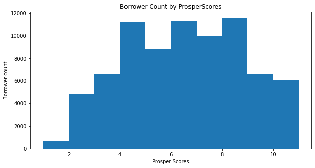

```python
#Plot the distribution of Borrowers by ProsperScore
plt.figure(figsize=(10, 5))
plt.hist(data=loan_copy, x='ProsperScore')
plt.title('Borrower Count by ProsperScores')
plt.xlabel('Prosper Scores')
plt.ylabel('Borrower count')
plt.show();
```

### Observation

Prosper Scores range from 1-11 and the higher this score, the higher the creditworthiness Majority of Borrowers has a Prosper Score of between 4 and 8, which will be considered average scores

### Question

Next up, the predictor variable of interest: LoanOriginalAmount

### Visualization

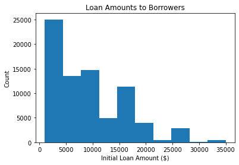

```python
# Plot the distribution of LoanOriginalAmount
plt.hist(data=loan_copy, x='LoanOriginalAmount')
plt.xlabel('Initial Loan Amount ($)')
plt.ylabel('Count')
plt.title('Loan Amounts to Borrowers')
plt.show()
```

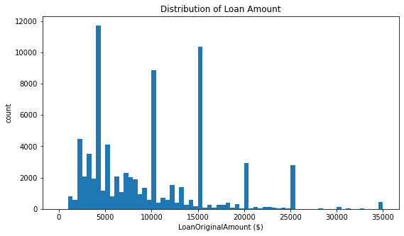

```python
# Plot the distribution of LoanOriginalAmount with smaller bins
binsize = 500
bins = np.arange(0, loan_copy['LoanOriginalAmount'].max()+binsize, binsize)

plt.figure(figsize=[9, 5])
plt.hist(data = loan_copy, x = 'LoanOriginalAmount', bins = bins)
plt.xlabel('LoanOriginalAmount ($)')
plt.ylabel('count')
plt.title('Distribution of Loan Amount');
plt.show()
```

### Observation

Majority of Loan Amounts borrowed ranged from approximately 1k to 15k dollars, with peaks at 5k, 10k and 15k and amounts borrowed capped at 35k dollars.

### Question

Next up, the predictor variable of interest: Borrower Rate

### Visualization

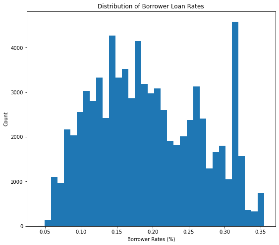

```python
# Plot the distribution of BorrowerRate
rate_bins = np.arange(loan_copy.BorrowerRate.min(), loan_copy.BorrowerRate.max(), 0.009)

plt.figure(figsize = [9, 8])
plt.hist(data=loan_copy, x='BorrowerRate', bins=rate_bins)
plt.xlabel('Borrower Rates (%)');
plt.ylabel('Count')
plt.title('Distribution of Borrower Loan Rates');
```

### Question

How were Borrowers' loan amounts affected by location

```python
#Borrower Distribution by location/State
location = loan_copy['BorrowerState'].value_counts()
location[0:10]
```

```
CA    9745
NY    5285
TX    5168
FL    4829
IL    3927
OH    3118
GA    3055
VA    2569
NJ    2503
PA    2458
Name: BorrowerState, dtype: int64
```

### Visualization

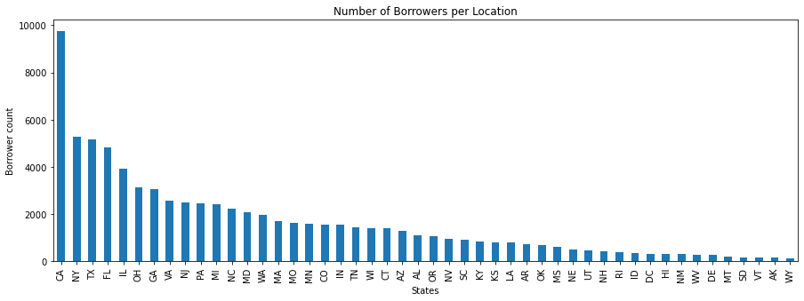

```python
#Plot the distribution of Borrowers by location/State
plt.figure(figsize=(15, 5))
location.plot(kind='bar');

plt.title('Number of Borrowers per Location');
plt.xlabel('States');
plt.ylabel('Borrower count');

plt.xticks(rotation=90);
```